# Explore Wine data by Zhongwei Teng

# Multivariate Plots Section

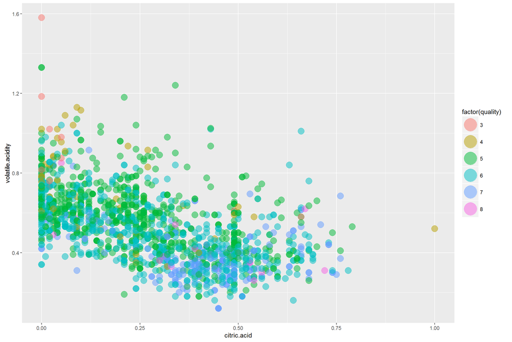

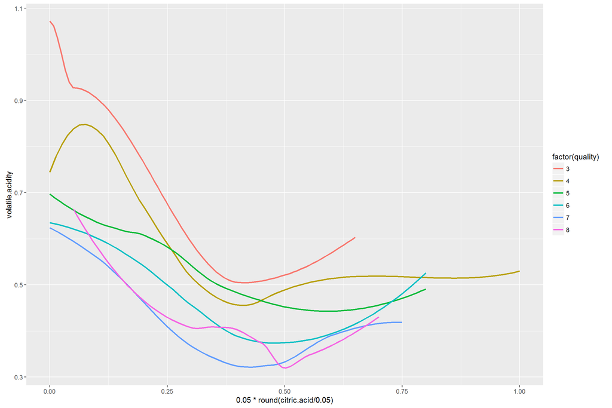

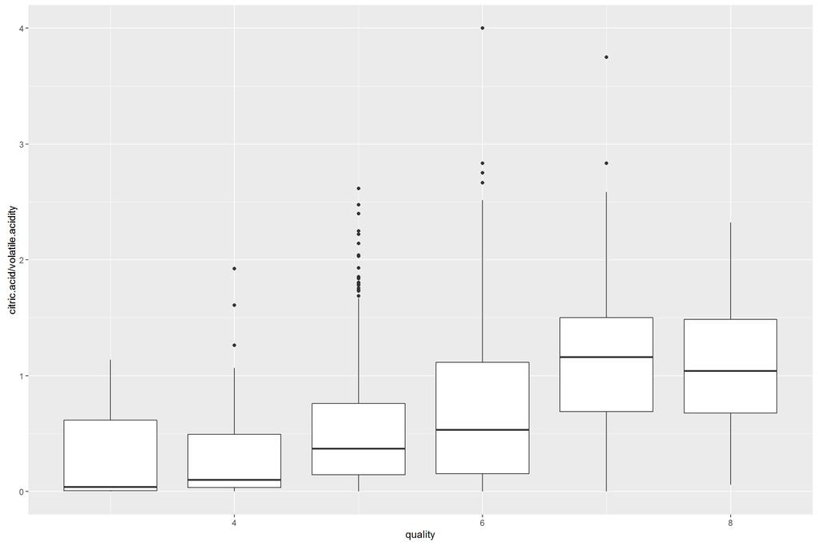

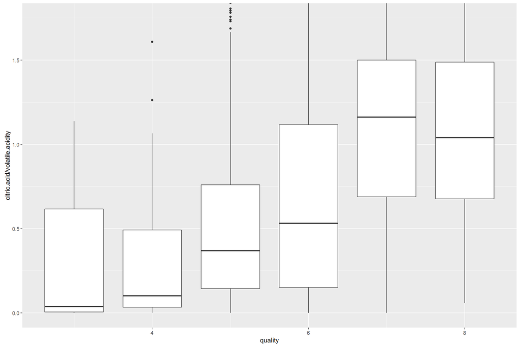

The trend is more clear. When quality become better, citric.acid/volatile.acidity will increase dramatically. Then it tends to flat when quality reach 7.

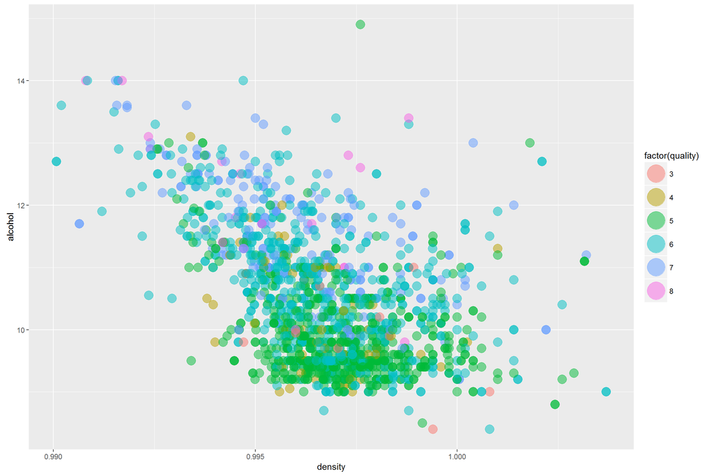

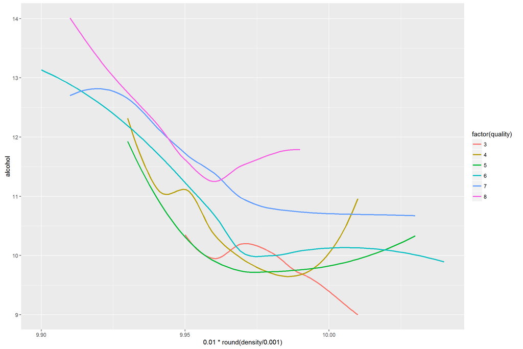

We can see good quality wine tend to be upper left side. We can use alcohol/density to investigate.

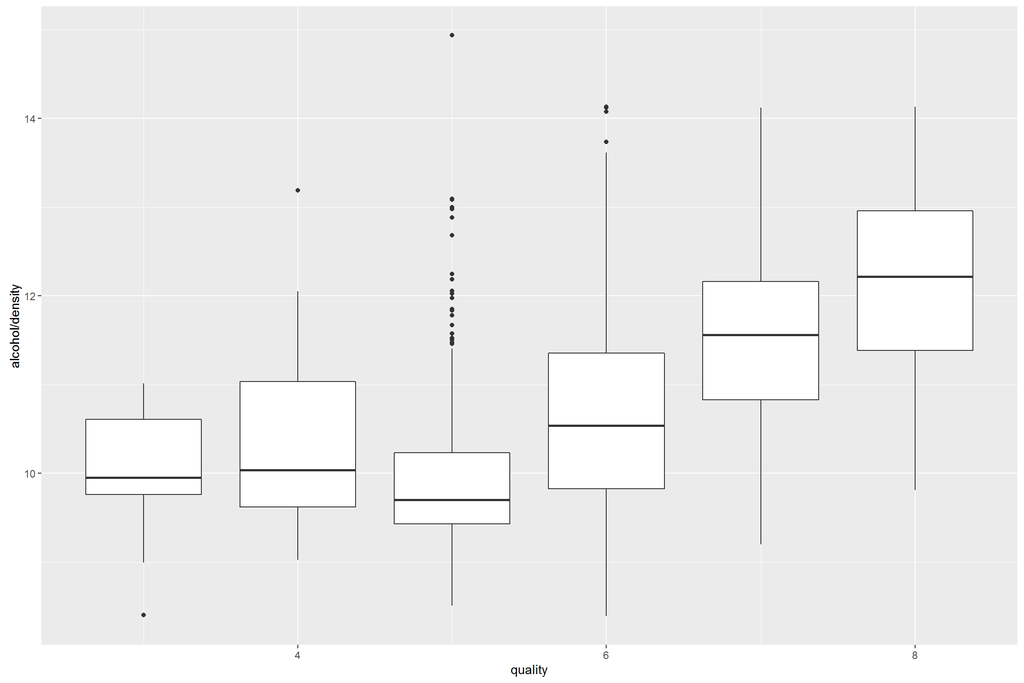

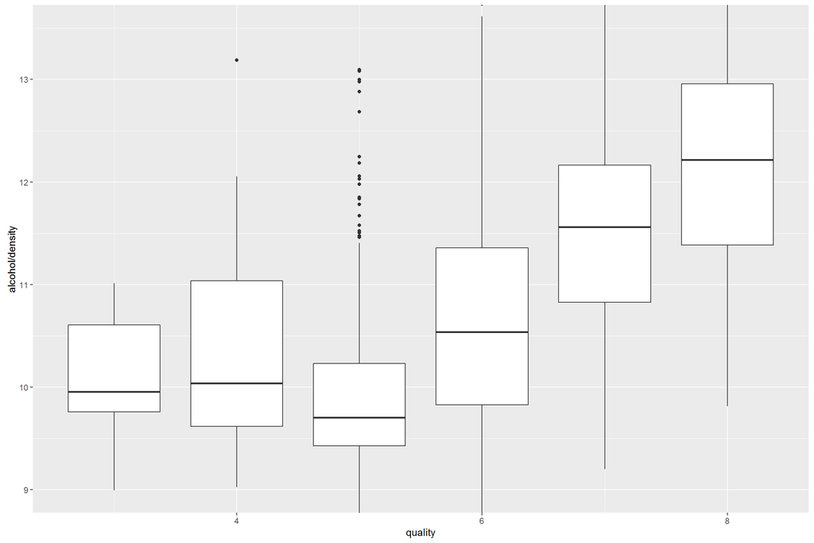

The left side of this figure is flat and the right side is similar with a linear model. Then we will build a linear model using what we find before.

```
##
## Calls:
## m1: lm(formula = I(quality) ~ I(alcohol), data = wine)
## m2: lm(formula = I(quality) ~ I(alcohol) + density, data = wine)
## m3: lm(formula = I(quality) ~ I(alcohol) + density + volatile.acidity,
##     data = wine)
## m4: lm(formula = I(quality) ~ I(alcohol) + density + volatile.acidity +
##     log(citric.acid + 1), data = wine)
##
## =======================================================================
##                            m1          m2          m3          m4
## -----------------------------------------------------------------------
##   (Intercept)            1.875***  -33.152**   -18.407     -21.713
##                         (0.175)    (10.878)    (10.298)    (11.938)
##   I(alcohol)             0.361***    0.391***    0.333***    0.336***
##                         (0.017)     (0.019)     (0.018)     (0.019)
##   density                           34.822**    21.360*     24.686*
##                                    (10.813)    (10.228)    (11.896)
##   volatile.acidity                              -1.365***   -1.403***
##                                                 (0.096)     (0.118)
##   log(citric.acid + 1)                                      -0.084
##                                                             (0.154)
## -----------------------------------------------------------------------
##   R-squared                  0.2        0.2         0.3         0.3
##   adj. R-squared             0.2        0.2         0.3         0.3
##   sigma                      0.7        0.7         0.7         0.7
##   F                        468.3      240.7       248.9       186.7
##   p                          0.0        0.0         0.0         0.0
##   Log-likelihood         -1721.1    -1715.9     -1619.6     -1619.5
##   Deviance                 805.9      800.7       709.9       709.7
##   AIC                     3448.1     3439.8      3249.3      3251.0
##   BIC                     3464.2     3461.3      3276.1      3283.2
##   N                       1599       1599        1599        1599
## =======================================================================
```

The result can’t be worse! Apparently, using linear model is not a good choice in this problem. Our prediction is far away from the actual quality.

# Multivariate Analysis

### Talk about some of the relationships you observed in this part of the investigation. Were there features that strengthened each other in terms of looking at your feature(s) of interest?

We make scatter plot of volatile.acidity and citric.acid and we find the distribution shows a regulation, like a stair. So we decide use citric.acid/volatile.acidit to explore our data. The result is satisfied, the trend is more clear than before. We do the same step to ‘alcohol’ and ‘density’ and we get similar result.

### Were there any interesting or surprising interactions between features?

Both volatile.acidity-citric.acid and alcohol-density exist a flat area and the rest of them seem to be linear model.

### OPTIONAL: Did you create any models with your dataset? Discuss the strengths and limitations of your model.

I create a linear model and like what I see in the plot, it doesn’t work at all. What we need is a non-linear model.

# Final Plots and Summary

### Plot One

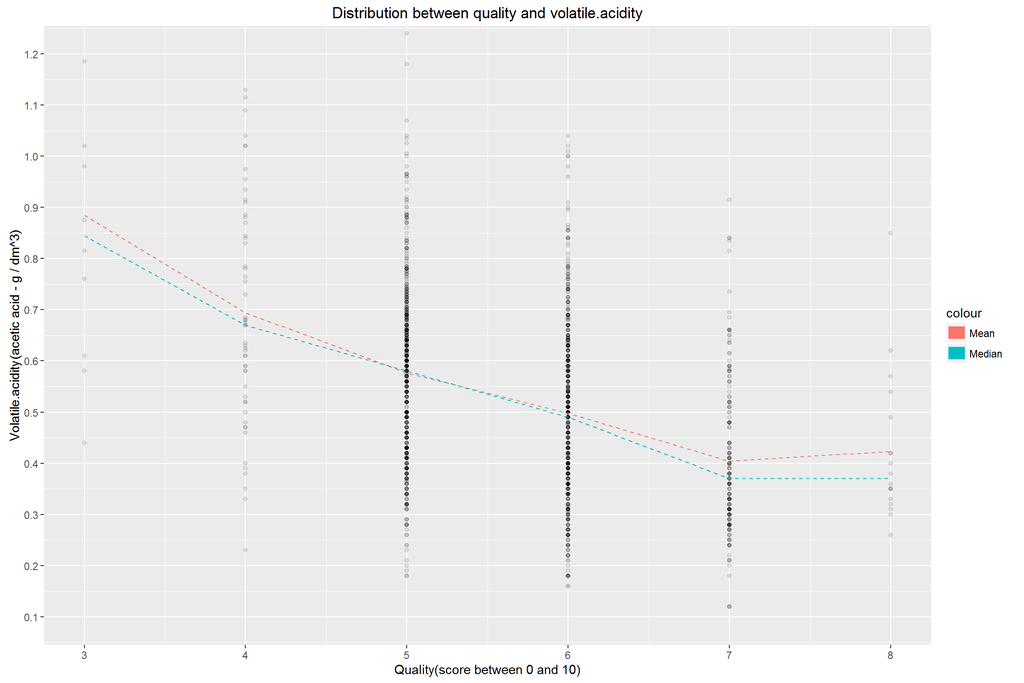

### Description One

Quality of wine has strong correlation with volatile.acidity.The median and mean in each quality group are very close. High quality wine tend to have lower volatile.acidity. Most wine’s quality range from 5 to 6 and their mean of volatile.acidity range from 0.5 to 0.6.

### Plot Two

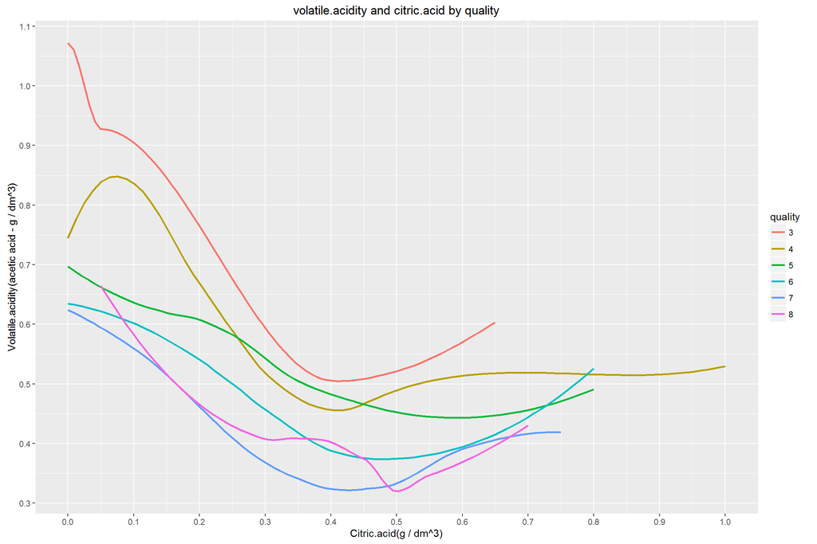

### Description Two

We find a negative correlation between volatile.acidity and citric.acid. When citric.acid reach 0.5 g/dm^3, the curve tends to be flat. Moreover, it’s clearly that high quality wine more likely be high citric.acid and low volatile.acidity.

### Plot Three

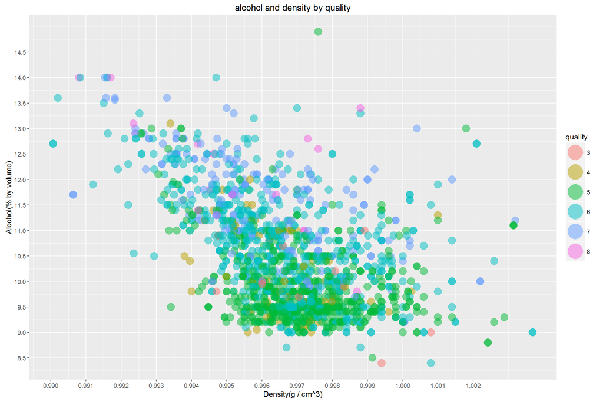

# Reflection

This dataset includes 1599 observation and 13 variables. It describe main features of different wine and its quality. When I got this data, I felt overwhelmed since I only knew few of these features, like alcohol. Before I started my exploration, this dataset was just number. I began this project by investigating single variable. Analyzing the distribution of each variable is important for next work. Then I chose 5 features according to the correlation figure. I tried to figure out the relationship between two of them. Finally, I plotted graphics using multiple features and created a linear model.

When I processed this dataset at the beginning, the plot is not very clear because almost all of them need adjustment of axis. For these long-tailed figure, dense breaks will make the plot blur. But loose breaks will let us lose some information. For this trade off, I chose to change the number of breaks depending on the density of data and it made my plot more clear.

If we want a better result, we need both more detailed data and appropriate non-linear model. Many of features can’t be used in our analysis, so we need get some new features which have relatively strong correlation with quality, volatile.acidity or alcohol. Meanwhile, more observations are required. On the other hand, we need an effective model to fit our data. Simplified linear model has been proven that it didn’t work for current data. Considering the limited number of observation and features, support vector machine can be good choice.